# R Notebook

Load the libraries

Set the factors

```r
treatment_pattern <- (rep(c("Untreated", "Treatment"), times = 9))
treatment <- factor(c(treatment_pattern))

donor_pattern <- c(rep("M24", times = 6), rep("M31", times = 6), rep("M32", times = 6))
donors <- factor(c(donor_pattern))
```

Cbind the factors

```r
groups <- data.frame(sample = colnames(counts), treatment, donors)

cbind(groups,colnames(counts))
```

| sample | treatment | donors | colnames(counts) |
| --- | --- | --- | --- |
| CF_M24_EV1 | Untreated | M24 | CF_M24_EV1 |
| CF_M24_EVPA1 | Treatment | M24 | CF_M24_EVPA1 |
| CF_M24_EV2 | Untreated | M24 | CF_M24_EV2 |
| CF_M24_EVPA2 | Treatment | M24 | CF_M24_EVPA2 |
| CF_M24_EV3 | Untreated | M24 | CF_M24_EV3 |
| CF_M24_EVPA3 | Treatment | M24 | CF_M24_EVPA3 |
| CF_M31_EV1 | Untreated | M31 | CF_M31_EV1 |
| CF_M31_EVPA1 | Treatment | M31 | CF_M31_EVPA1 |
| CF_M31_EV2 | Untreated | M31 | CF_M31_EV2 |
| CF_M31_EVPA2 | Treatment | M31 | CF_M31_EVPA2 |

[output cut: 8 more lines]

```r
NA
```

#Part 1 – Exploratory Analysis #1. Visualize your library sizes.

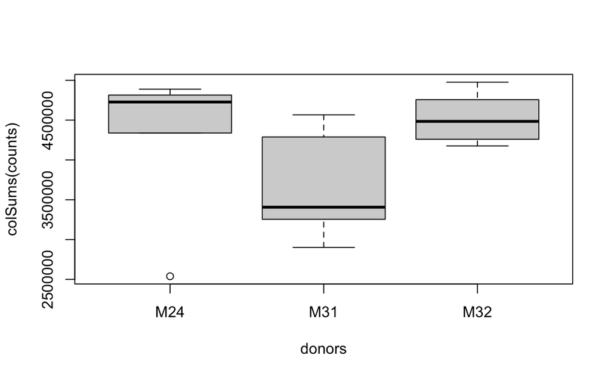

```r
boxplot(colSums(counts) ~ donors)
```

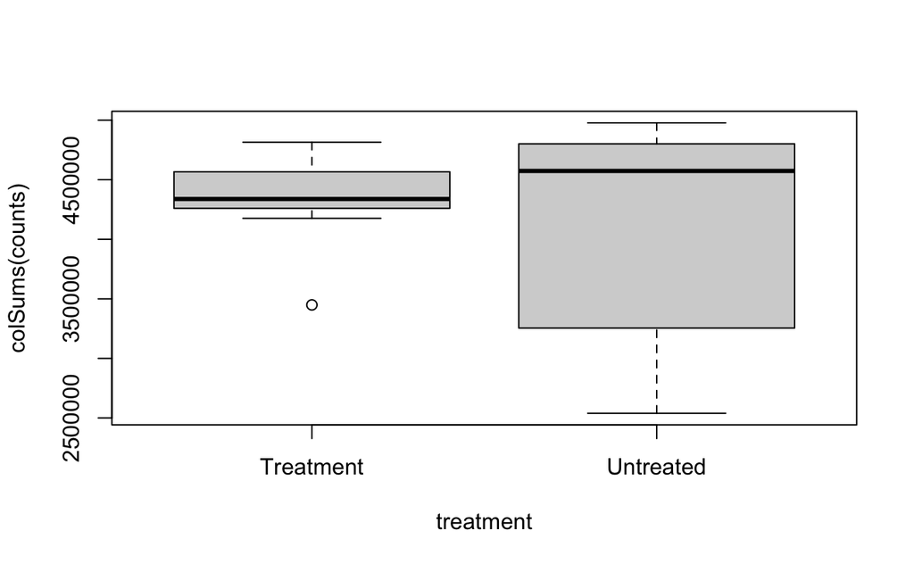

```r
boxplot(colSums(counts) ~ treatment)
```

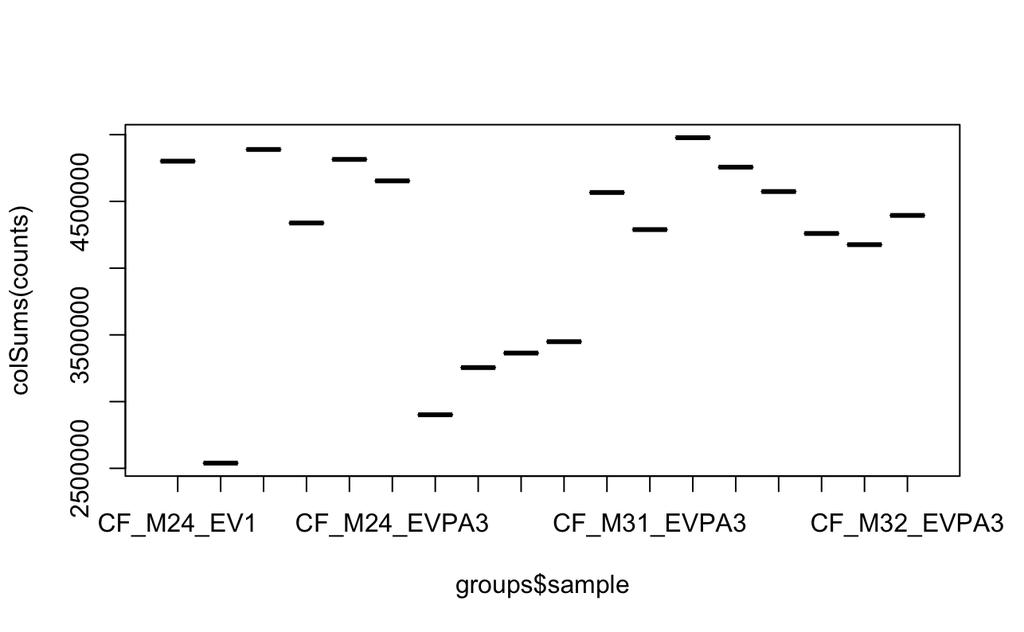

```r
boxplot(colSums(counts) ~ groups$sample)
```

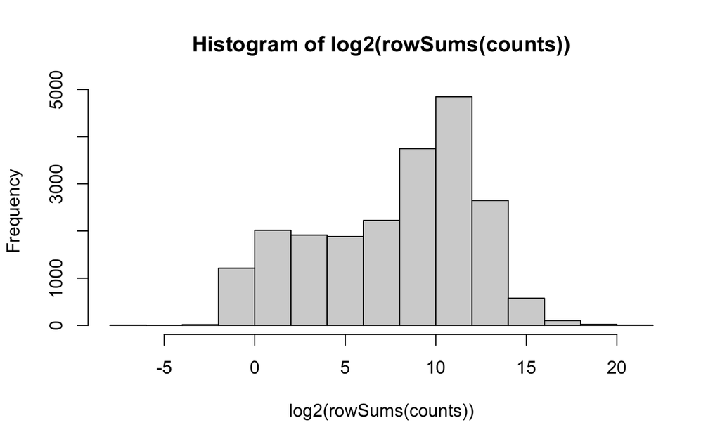

```r
hist(log2(rowSums(counts)))
```

#3. Determine how many genes had zero counts and remove these genes (rows) from the data set. What does your count distribution look like before and after this?

```r
MinVals <- apply(counts, 1, min)
sum(MinVals == 0)
```

```
[1] 24868
```

```r
Exp <- counts[MinVals > 0, ]
```

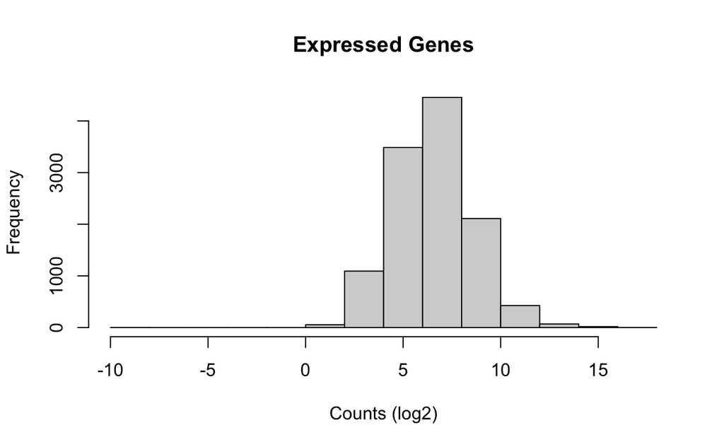

```r
ExpLog2 <- log2(Exp)
hist(rowMeans(ExpLog2), xlab = "Counts (log2)", main = "Expressed Genes")
```

#4. Make a boxplot of log2 raw counts after removing all genes that had zero counts.

Plot “raw” (our log2 transformed) sample counts

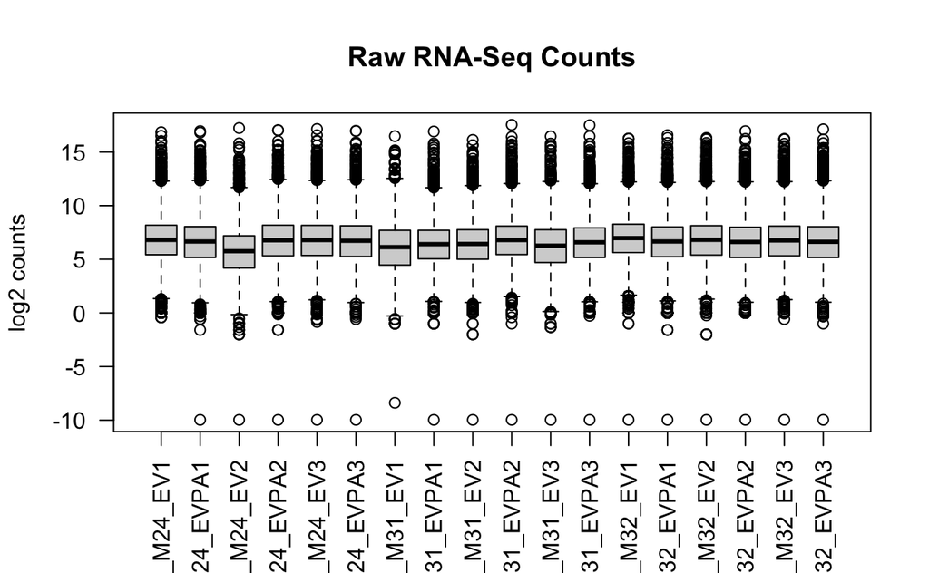

```r
boxplot(ExpLog2, ylab = "log2 counts", main = "Raw RNA-Seq Counts", las = 2)
```

#5. Make a Cluster Dendrogram of the raw data.

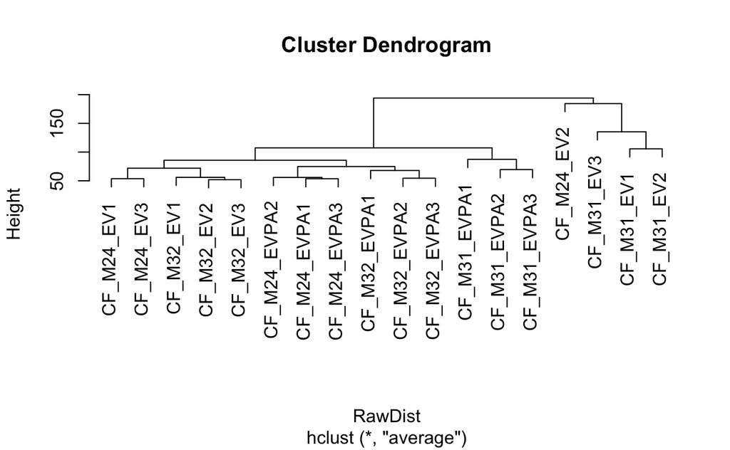

```r
RawDist <- dist(t(ExpLog2), method = "euclidean")
plot(hclust(RawDist, method = "average"))
```

Simple normalization

```r
SampleMedians <- apply(ExpLog2, 2, median) # Find the median value of each column - 2 means column
GrandMedian <- mean(SampleMedians) # Take the average of those
CorrectionFactors <- GrandMedian - SampleMedians # Calculate correction factor to apply to data
CorrectionFactors
```

```
  CF_M24_EV1 CF_M24_EVPA1   CF_M24_EV2 CF_M24_EVPA2   CF_M24_EV3 CF_M24_EVPA3
-0.219473027 -0.070329588  0.832994393 -0.180937605 -0.206533972 -0.140038560
  CF_M31_EV1 CF_M31_EVPA1   CF_M31_EV2 CF_M31_EVPA2   CF_M31_EV3 CF_M31_EVPA3
 0.453085963  0.178490959  0.157864308 -0.206533972  0.321095354  0.002904366
  CF_M32_EV1 CF_M32_EVPA1   CF_M32_EV2 CF_M32_EVPA2   CF_M32_EV3 CF_M32_EVPA3
-0.389398029 -0.071942790 -0.225924944 -0.026827949 -0.167005607 -0.041489298
```

These correction factors will align the medians of all of our samples This changes our counts just enough to correct for variability between samples/groups without loosing any actual effects of changes in gene expression.

Loop through each column (sample) and fill in medians adjusted with sample correction factor

```r
ExpNorm <- ExpLog2

for(col in colnames(ExpNorm)){
  ExpNorm[, col] <- ExpLog2[, col] + CorrectionFactors[col]
}
```

#6. Do a simple normalization of your data and visualize your normalized data with a boxplot of log2 raw counts and a cluster dendrogram. Did normalization change anything?

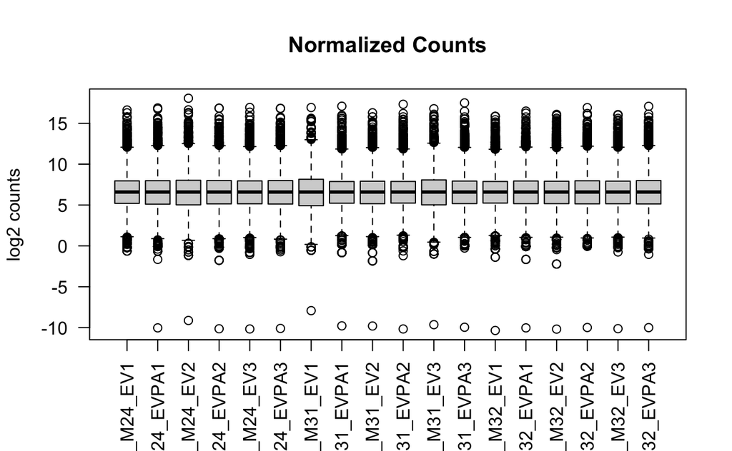

```r
boxplot(ExpNorm, ylab = "log2 counts", main = "Normalized Counts", las = 2)
```

```r
NormDist <- dist(t(ExpNorm), method = "euclidean")
plot(hclust(NormDist, method = "average"))
```

[output not shown]

#7 Make a PCA plot and use color to highlight groups

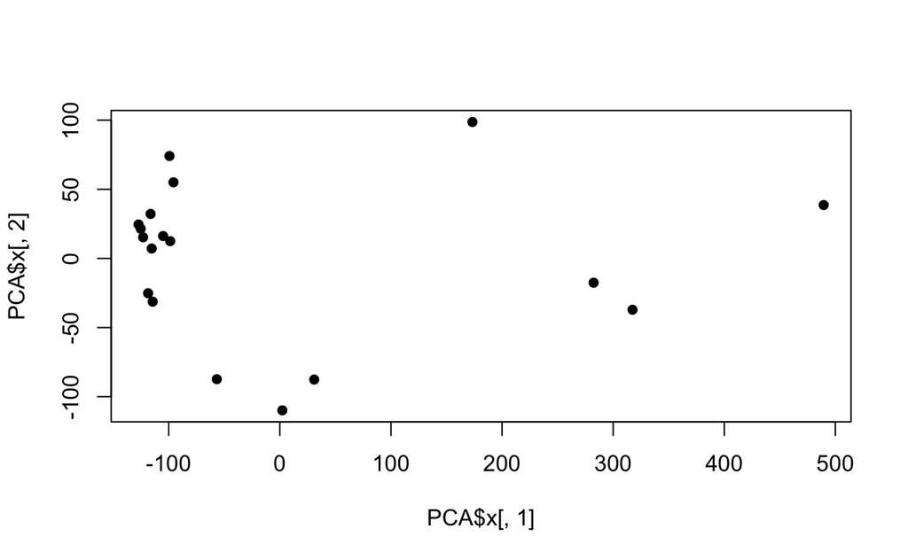

```r
PCA <- prcomp(t(NormDist))
plot(PCA$x[ , 1], PCA$x[ , 2], pch = 16)
```

By donor

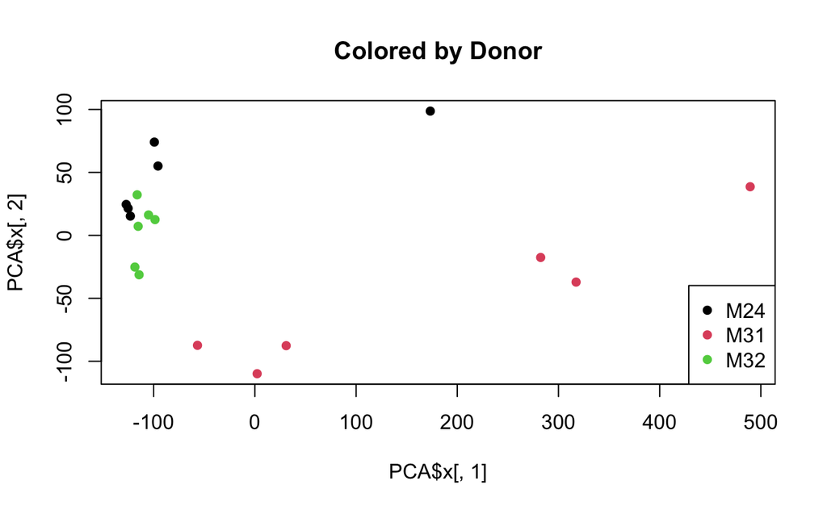

```r
plot(PCA$x[ , 1], PCA$x[ , 2], pch = 16, col = donors,
     main = "Colored by Donor")
legend("bottomright", legend = unique(donors), pch = 16, col = unique(donors))
```

By treatment

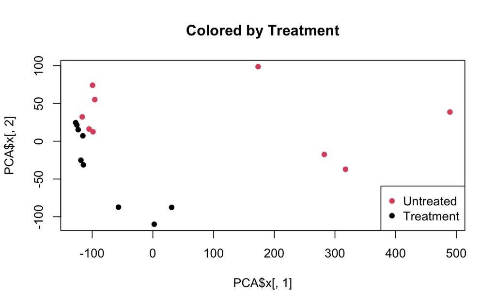

```r
plot(PCA$x[ , 1], PCA$x[ , 2], pch = 16, col = treatment,
     main = "Colored by Treatment")
legend("bottomright", legend = unique(treatment), pch = 16, col = unique(treatment))
```